# How Can a Wellness Technology Company Play It Smart?

###### Relationship between steps and sedentary minutes in Daily_Activity with Graphs

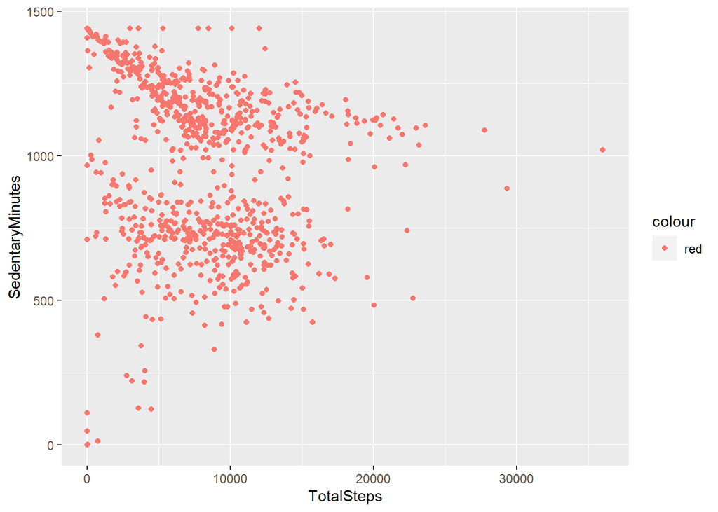

```r
ggplot(data = Daily_Activity, aes(x=TotalSteps, y=SedentaryMinutes, colour = "red")) + geom_point()
```

###### Finding relationship between total time in bed and total minutes asleep from Sleep_Day Data

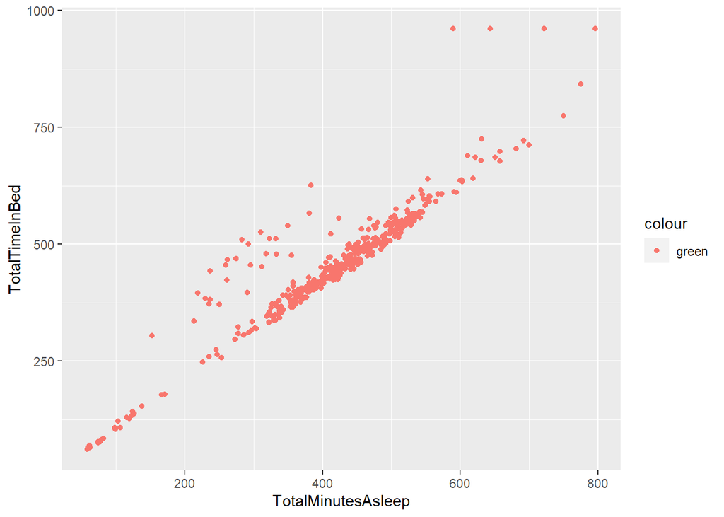

```r
ggplot(data = Sleep_Day, aes(x = TotalMinutesAsleep, y = TotalTimeInBed, color = "green")) +geom_point()
```

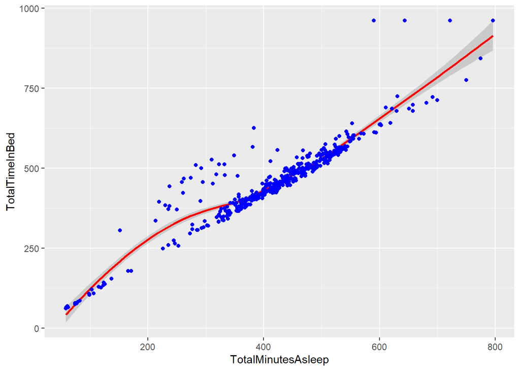

```r
ggplot(data = Sleep_Day) + geom_smooth(mapping= aes(x=TotalMinutesAsleep, y=TotalTimeInBed),color = "red") + geom_point(mapping= aes(x=TotalMinutesAsleep, y=TotalTimeInBed),color= "blue")
```

###### Finding relationship between Very Active Minutes and Very Active Distance from Weight_Log data with Graphs

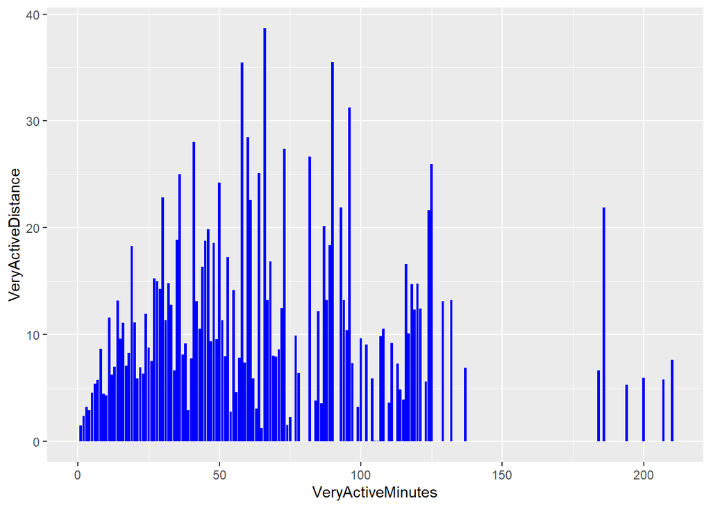

```r
ggplot(data = Weight_Log) +
  geom_col(mapping = aes(x = VeryActiveMinutes, y = VeryActiveDistance), fill = "blue")
```

##### Merging Daily Activity and Sleep Day dataset

```r
DailyActivity_SleepDay <- merge(Daily_Activity, Sleep_Day, all = TRUE)

view(DailyActivity_SleepDay)

colnames(DailyActivity_SleepDay)
```

```
##  [1] "Id"                       "ActivityDate"
##  [3] "TotalSteps"               "TotalDistance"
##  [5] "TrackerDistance"          "LoggedActivitiesDistance"
##  [7] "VeryActiveDistance"       "ModeratelyActiveDistance"
##  [9] "LightActiveDistance"      "SedentaryActiveDistance"
## [11] "VeryActiveMinutes"        "FairlyActiveMinutes"
## [13] "LightlyActiveMinutes"     "SedentaryMinutes"
## [15] "Calories"                 "SleepDay"
## [17] "TotalSleepRecords"        "TotalMinutesAsleep"
## [19] "TotalTimeInBed"
```

###### Number of unique participants in combined dataset

```r
n_distinct(DailyActivity_SleepDay$Id)
```

```
## [1] 33
```

###### User activities in minutes through Pie Chart

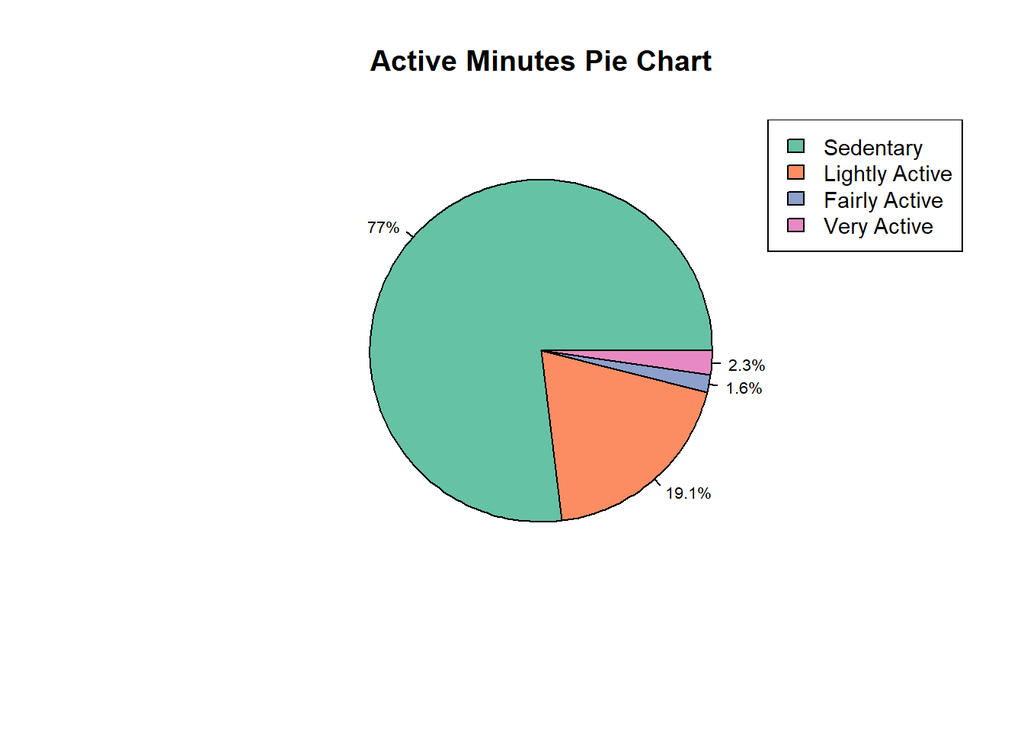

```r
Sedentary <- sum(DailyActivity_SleepDay$SedentaryMinutes)
Active <- sum(DailyActivity_SleepDay$VeryActiveMinutes)
Fairly <- sum(DailyActivity_SleepDay$FairlyActiveMinutes)
Lightly <- sum(DailyActivity_SleepDay$LightlyActiveMinutes)

x <- c(Sedentary,Lightly,Fairly,Active)
labels <- c("Sedentary", "Lightly Active", "Fairly Active", "Very Active")

piepercent <- round(100*x/sum(x),1)

labels <- paste0(piepercent,"%")

colour = brewer.pal(length(piepercent), "Set2")

pie(x,labels = labels, main = "Active Minutes Pie Chart", col = colour, cex = 0.65)


legend("topright",c("Sedentary","Lightly Active", "Fairly Active", "Very Active"), cex = 0.9, fill = colour)
```

###### Add a new coloumn in the combined dataset converting ‘char’ into ‘Date’.

```r
DailyActivity_SleepDay$ActivityDate2 <- mdy(DailyActivity_SleepDay$ActivityDate)

colnames(DailyActivity_SleepDay)
```

```
##  [1] "Id"                       "ActivityDate"
##  [3] "TotalSteps"               "TotalDistance"
##  [5] "TrackerDistance"          "LoggedActivitiesDistance"
##  [7] "VeryActiveDistance"       "ModeratelyActiveDistance"
##  [9] "LightActiveDistance"      "SedentaryActiveDistance"
## [11] "VeryActiveMinutes"        "FairlyActiveMinutes"
## [13] "LightlyActiveMinutes"     "SedentaryMinutes"
## [15] "Calories"                 "SleepDay"
## [17] "TotalSleepRecords"        "TotalMinutesAsleep"
## [19] "TotalTimeInBed"           "ActivityDate2"
```

###### convert activity date into days of week.

```r
DailyActivity_SleepDay$weekday <- wday(DailyActivity_SleepDay$ActivityDate2, label = TRUE)

colnames(DailyActivity_SleepDay)
```

```
##  [1] "Id"                       "ActivityDate"
##  [3] "TotalSteps"               "TotalDistance"
##  [5] "TrackerDistance"          "LoggedActivitiesDistance"
##  [7] "VeryActiveDistance"       "ModeratelyActiveDistance"
##  [9] "LightActiveDistance"      "SedentaryActiveDistance"
## [11] "VeryActiveMinutes"        "FairlyActiveMinutes"
## [13] "LightlyActiveMinutes"     "SedentaryMinutes"
## [15] "Calories"                 "SleepDay"
## [17] "TotalSleepRecords"        "TotalMinutesAsleep"
## [19] "TotalTimeInBed"           "ActivityDate2"
## [21] "weekday"
```

```r
head(DailyActivity_SleepDay$weekday)
```

```
## [1] Sat Sat Sat Sat Sat Sat
## Levels: Sun < Mon < Tue < Wed < Thu < Fri < Sat
```

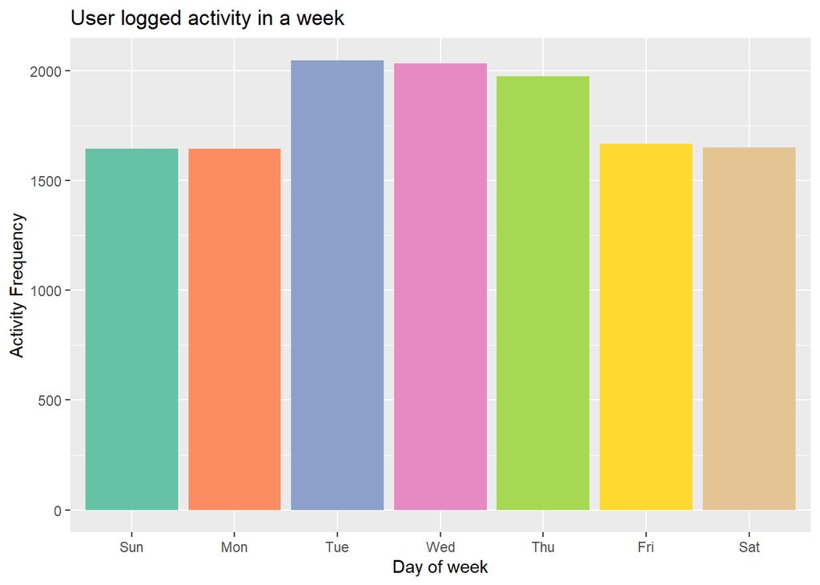

```r
ggplot(data = DailyActivity_SleepDay, aes(x = weekday)) + geom_bar(fill = brewer.pal(7, "Set2")) + labs(title = "User logged activity in a week", x = "Day of week", y = "Activity Frequency")
```

## 5. Share

1. Positive correlation between total steps and calories burnt.
2. Negative correlation between total steps and sedenatary minutes.
3. Positive correlation between total minutes in bed and total minutes asleep.
4. Daily activity high in mid of the week.